# University Admission Prediction

This project analyze the dataset from https://www.kaggle.com/mohansacharya/graduate-admissions and predicts if a student will get an admission (on based on his/her GRE score, GPA score and University rank) to university or not.

The dataset contains several parameters which are considered important during the application for Masters Programs. The parameters included are :

GRE Scores ( out of 340 )

TOEFL Scores ( out of 120 )

University Rating ( out of 5 )

Statement of Purpose and Letter of Recommendation Strength ( out of 5 )

Undergraduate GPA ( out of 10 )

Research Experience ( either 0 or 1 )

Chance of Admit ( ranging from 0 to 1 ) is the Target Variable

Find the overall accuracy with different Sklearn Machine learning modules like

Linear Regression

Support Vector Machine

XG BOOST

DecisionTreeRegressor

## IMPORTING THE LIBRARIES

```python
import pandas as pd
import numpy as np
import matplotlib.pyplot as plt
import seaborn as sns
%matplotlib inline
```

## UPLOADING THE FILES TO GOOGLE DRIVE

```python
from google.colab import files
uploaded=files.upload()
```

Upload widget is only available when the cell has been executed in the current browser session. Please rerun this cell to enable.

```
Saving Admission_Predict_Ver1.1.csv to Admission_Predict_Ver1.1.csv
```

```python
import io
data=pd.read_csv(io.BytesIO(uploaded["Admission_Predict_Ver1.1.csv"]))
```

## EDA

```python
data.shape
```

```
(500, 9)
```

```python
data.head()
```

|  | Serial No. | GRE Score | TOEFL Score | University Rating | SOP | LOR | CGPA | Research | Chance of Admit |
| --- | --- | --- | --- | --- | --- | --- | --- | --- | --- |
| 0 | 1 | 337 | 118 | 4 | 4.5 | 4.5 | 9.65 | 1 | 0.92 |
| 1 | 2 | 324 | 107 | 4 | 4.0 | 4.5 | 8.87 | 1 | 0.76 |
| 2 | 3 | 316 | 104 | 3 | 3.0 | 3.5 | 8.00 | 1 | 0.72 |
| 3 | 4 | 322 | 110 | 3 | 3.5 | 2.5 | 8.67 | 1 | 0.80 |
| 4 | 5 | 314 | 103 | 2 | 2.0 | 3.0 | 8.21 | 0 | 0.65 |

```python
data.columns
```

```
Index(['Serial No.', 'GRE Score', 'TOEFL Score', 'University Rating', 'SOP',
       'LOR ', 'CGPA', 'Research', 'Chance of Admit '],
      dtype='object')
```

```python
data.describe()
```

|  | Serial No. | GRE Score | TOEFL Score | University Rating | SOP | LOR | CGPA | Research | Chance of Admit |
| --- | --- | --- | --- | --- | --- | --- | --- | --- | --- |
| count | 500.000000 | 500.000000 | 500.000000 | 500.000000 | 500.000000 | 500.00000 | 500.000000 | 500.000000 | 500.00000 |
| mean | 250.500000 | 316.472000 | 107.192000 | 3.114000 | 3.374000 | 3.48400 | 8.576440 | 0.560000 | 0.72174 |
| std | 144.481833 | 11.295148 | 6.081868 | 1.143512 | 0.991004 | 0.92545 | 0.604813 | 0.496884 | 0.14114 |
| min | 1.000000 | 290.000000 | 92.000000 | 1.000000 | 1.000000 | 1.00000 | 6.800000 | 0.000000 | 0.34000 |
| 25% | 125.750000 | 308.000000 | 103.000000 | 2.000000 | 2.500000 | 3.00000 | 8.127500 | 0.000000 | 0.63000 |
| 50% | 250.500000 | 317.000000 | 107.000000 | 3.000000 | 3.500000 | 3.50000 | 8.560000 | 1.000000 | 0.72000 |
| 75% | 375.250000 | 325.000000 | 112.000000 | 4.000000 | 4.000000 | 4.00000 | 9.040000 | 1.000000 | 0.82000 |
| max | 500.000000 | 340.000000 | 120.000000 | 5.000000 | 5.000000 | 5.00000 | 9.920000 | 1.000000 | 0.97000 |

```python
data.info()
```

```
<class 'pandas.core.frame.DataFrame'>
RangeIndex: 500 entries, 0 to 499
Data columns (total 9 columns):
 #   Column             Non-Null Count  Dtype
---  ------             --------------  -----
 0   Serial No.         500 non-null    int64
 1   GRE Score          500 non-null    int64
 2   TOEFL Score        500 non-null    int64
 3   University Rating  500 non-null    int64
 4   SOP                500 non-null    float64
 5   LOR                500 non-null    float64
 6   CGPA               500 non-null    float64
 7   Research           500 non-null    int64
 8   Chance of Admit    500 non-null    float64
dtypes: float64(4), int64(5)
memory usage: 35.3 KB
```

Check for misssing values

```python
data.isnull().sum()
```

```
Serial No.           0
GRE Score            0
TOEFL Score          0
University Rating    0
SOP                  0
LOR                  0
CGPA                 0
Research             0
Chance of Admit      0
dtype: int64
```

NO missing data

```python
data_university=data.groupby(by='University Rating').mean()
```

```python
data_university
```

| University Rating | Serial No. | GRE Score | TOEFL Score | SOP | LOR | CGPA | Research | Chance of Admit |
| --- | --- | --- | --- | --- | --- | --- | --- | --- |
| 1 | 281.558824 | 304.911765 | 100.205882 | 1.941176 | 2.426471 | 7.798529 | 0.294118 | 0.562059 |
| 2 | 249.555556 | 309.134921 | 103.444444 | 2.682540 | 2.956349 | 8.177778 | 0.293651 | 0.626111 |
| 3 | 247.574074 | 315.030864 | 106.314815 | 3.308642 | 3.401235 | 8.500123 | 0.537037 | 0.702901 |
| 4 | 275.809524 | 323.304762 | 110.961905 | 4.000000 | 3.947619 | 8.936667 | 0.780952 | 0.801619 |
| 5 | 207.753425 | 327.890411 | 113.438356 | 4.479452 | 4.404110 | 9.278082 | 0.876712 | 0.888082 |

## PLOTTING FEW GRAPHS

### Histogram of Numeric Variables¶

```
array([[<matplotlib.axes._subplots.AxesSubplot object at 0x7f97f3a99cc0>,
      dtype=object)
```

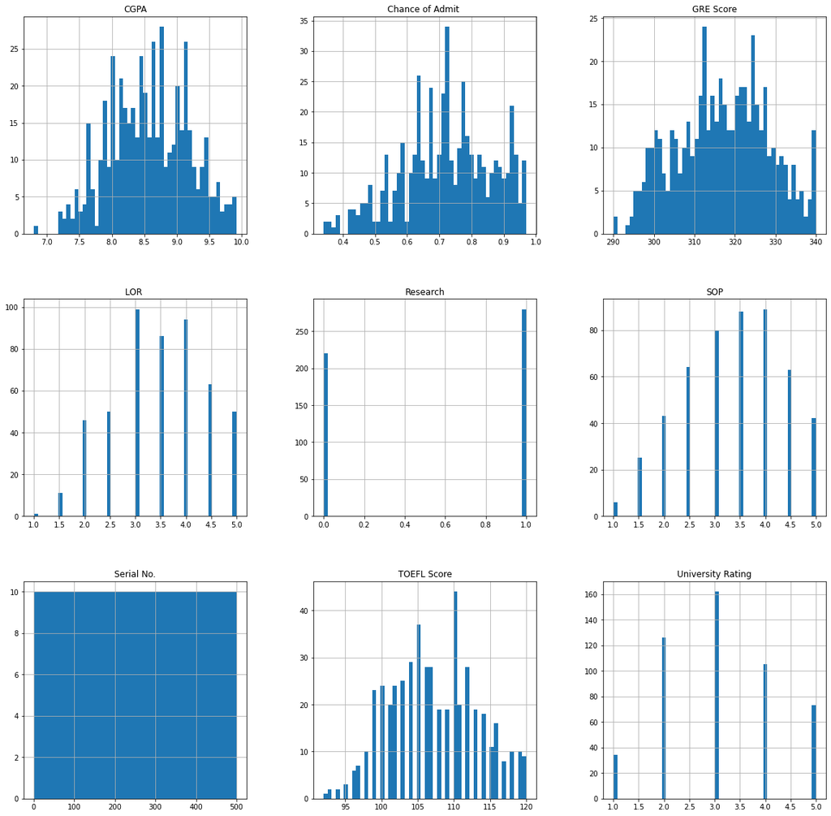

```python
data.hist(bins=50,figsize=(20,20))
```

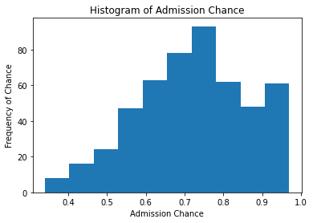

```python
plt.figure(figsize=(6,4))
plt.hist(data['Chance of Admit '],bins=10)
plt.title('Histogram of Admission Chance')
plt.xlabel('Admission Chance')
plt.ylabel('Frequency of Chance')
plt.show()
```

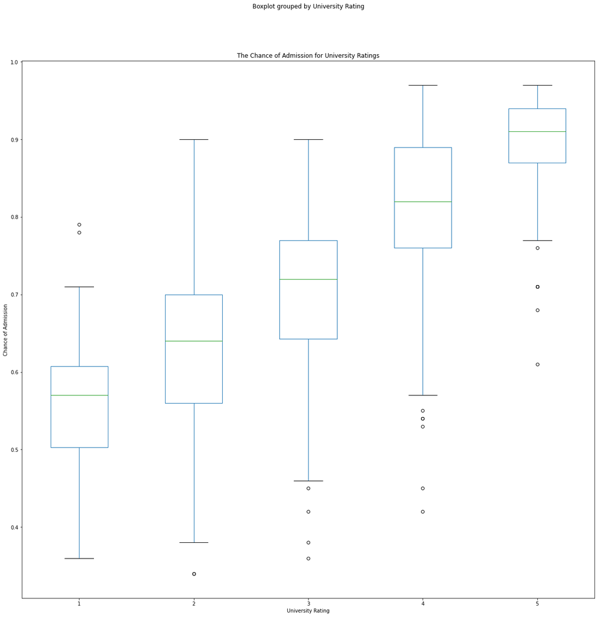

```python
data.boxplot(column="Chance of Admit ",by="University Rating",grid=False,figsize=(20,20))
plt.title('The Chance of Admission for University Ratings')
plt.xlabel('University Rating')
plt.ylabel('Chance of Admission')
plt.show()
```

Droping the serial No. column as its nit important for the analysis

```python
data=data.drop('Serial No.',axis=1)
```

```python
data.head()
```

|  | GRE Score | TOEFL Score | University Rating | SOP | LOR | CGPA | Research | Chance of Admit |
| --- | --- | --- | --- | --- | --- | --- | --- | --- |
| 0 | 337 | 118 | 4 | 4.5 | 4.5 | 9.65 | 1 | 0.92 |
| 1 | 324 | 107 | 4 | 4.0 | 4.5 | 8.87 | 1 | 0.76 |
| 2 | 316 | 104 | 3 | 3.0 | 3.5 | 8.00 | 1 | 0.72 |
| 3 | 322 | 110 | 3 | 3.5 | 2.5 | 8.67 | 1 | 0.80 |
| 4 | 314 | 103 | 2 | 2.0 | 3.0 | 8.21 | 0 | 0.65 |

Plotting the correlation matrix

```python
corr=data.corr()
corr.style.background_gradient(cmap='coolwarm').set_precision(2)
```

|  | GRE Score | TOEFL Score | University Rating | SOP | LOR | CGPA | Research | Chance of Admit |
| --- | --- | --- | --- | --- | --- | --- | --- | --- |
| GRE Score | 1.00 | 0.83 | 0.64 | 0.61 | 0.52 | 0.83 | 0.56 | 0.81 |
| TOEFL Score | 0.83 | 1.00 | 0.65 | 0.64 | 0.54 | 0.81 | 0.47 | 0.79 |
| University Rating | 0.64 | 0.65 | 1.00 | 0.73 | 0.61 | 0.71 | 0.43 | 0.69 |
| SOP | 0.61 | 0.64 | 0.73 | 1.00 | 0.66 | 0.71 | 0.41 | 0.68 |
| LOR | 0.52 | 0.54 | 0.61 | 0.66 | 1.00 | 0.64 | 0.37 | 0.65 |
| CGPA | 0.83 | 0.81 | 0.71 | 0.71 | 0.64 | 1.00 | 0.50 | 0.88 |
| Research | 0.56 | 0.47 | 0.43 | 0.41 | 0.37 | 0.50 | 1.00 | 0.55 |
| Chance of Admit | 0.81 | 0.79 | 0.69 | 0.68 | 0.65 | 0.88 | 0.55 | 1.00 |

```
array([[<matplotlib.axes._subplots.AxesSubplot object at 0x7f97f294c630>,
      dtype=object)
```

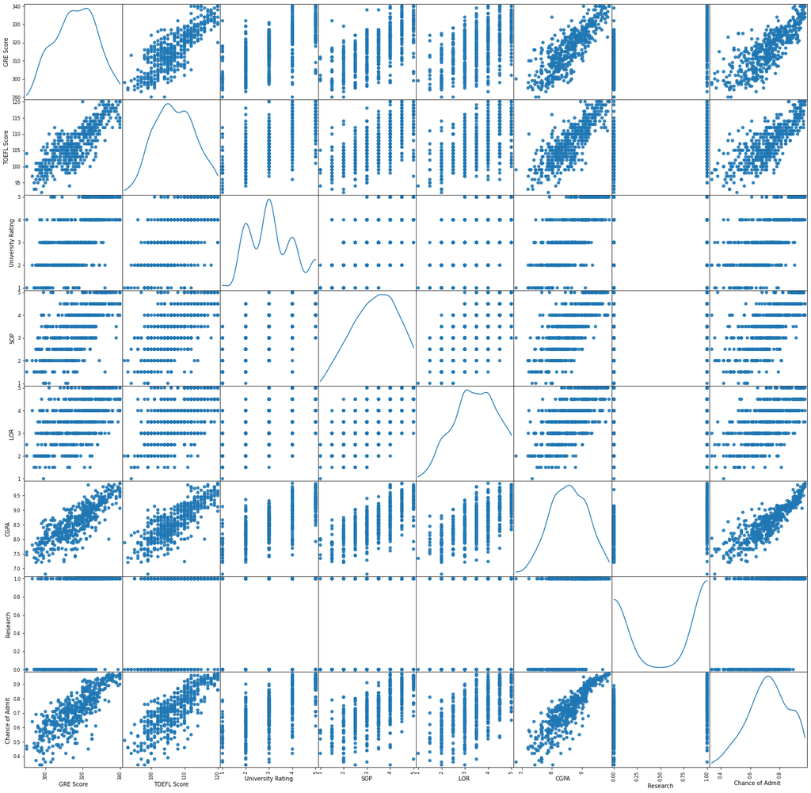

```python
from pandas.plotting import scatter_matrix
fig=plt.figure()
scatter_matrix(data,figsize=(25,25),alpha=0.9,diagonal="kde",marker="o")
```

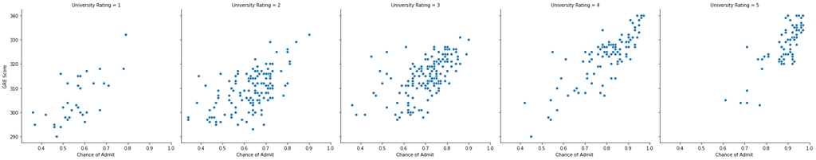

```python
sns.relplot(x="Chance of Admit ", y="GRE Score", col="University Rating", data=data)
```

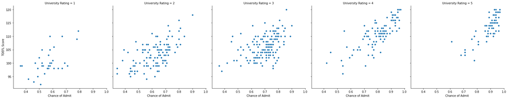

```python
sns.relplot(x="Chance of Admit ", y="TOEFL Score", col="University Rating", data=data)
```

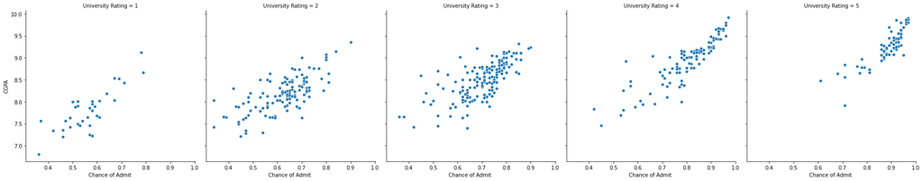

```python
sns.relplot(x="Chance of Admit ", y="CGPA", col="University Rating", data=data)
```

## SEPARATING THE FEATURES AND LABELS FROM THE DATA SET

```python
X=data.drop('Chance of Admit ',axis=1)
```

```python
y=data["Chance of Admit "]
```

VIEWING THE FEATURE DATASET X AND LABEL DATASET y

```python
X.shape
```

```
(500, 7)
```

```python
X.head()
```

|  | GRE Score | TOEFL Score | University Rating | SOP | LOR | CGPA | Research |
| --- | --- | --- | --- | --- | --- | --- | --- |
| 0 | 337 | 118 | 4 | 4.5 | 4.5 | 9.65 | 1 |
| 1 | 324 | 107 | 4 | 4.0 | 4.5 | 8.87 | 1 |
| 2 | 316 | 104 | 3 | 3.0 | 3.5 | 8.00 | 1 |
| 3 | 322 | 110 | 3 | 3.5 | 2.5 | 8.67 | 1 |
| 4 | 314 | 103 | 2 | 2.0 | 3.0 | 8.21 | 0 |

```python
y.shape
```

```
(500,)
```

```python
X=np.array(X)
y=np.array(y)
```

```python
y=y.reshape(-1,1)
```

```python
y.shape
```

```
(500, 1)
```

## FEATURE PROCESSING

```python
from sklearn.preprocessing import StandardScaler
sc=StandardScaler()
X=sc.fit_transform(X)
```

```python
X
```

```
array([[ 1.81923762,  1.77886545,  0.77558214, ...,  1.09894429,
         1.77680627,  0.88640526],
       [ 0.66714832, -0.03160087,  0.77558214, ...,  1.09894429,
         0.48585943,  0.88640526],
       [-0.0418297 , -0.52536441, -0.09979274, ...,  0.01730621,
        -0.95404281,  0.88640526],
       ...,
       [ 1.19888185,  2.10804114,  1.65095702, ...,  1.63976333,
         1.62785086,  0.88640526],
       [-0.39631872, -0.68995225,  0.77558214, ...,  1.63976333,
        -0.24236699, -1.12815215],
       [ 0.93301508,  0.95592621,  0.77558214, ...,  1.09894429,
         0.76721964, -1.12815215]])
```

```python
sc_y=StandardScaler()
y=sc_y.fit_transform(y)
```

```python
y
```

[output not shown]

[output cut: 445 more lines]

```
       [-0.15418528],
       [-0.29603006],
       [ 0.48411625],
       [ 0.27134907],
       [-0.50879724],
       [-0.36695246],
       [-1.28894355],
       [-1.35986594],
       [-0.72156441],
       [-0.29603006],
       [ 1.05149538],
       [ 1.68979691],
       [ 1.47702973],
       [ 0.0585819 ],
       [ 0.83872821]])
```

## SPLIT INTO TRAIN AND TEST SET

```python
from sklearn.model_selection import train_test_split
X_train,X_test,y_train,y_test=train_test_split(X,y,test_size=0.10,random_state=0)
```

### ANALYSIS OF THE SETS

```python
X_train.shape
```

```
(450, 7)
```

```python
X_train
```

```
array([[-0.92805224, -0.68995225, -0.97516761, ..., -0.52351283,
        -0.3582212 , -1.12815215],
       [-0.39631872, -1.01912795, -0.97516761, ...,  0.01730621,
        -0.88784041,  0.88640526],
       [-1.01667449, -0.68995225, -0.97516761, ...,  0.01730621,
        -0.73888501, -1.12815215],
       ...,
       [-2.34600829, -0.52536441,  0.77558214, ..., -1.06433187,
        -1.84777524, -1.12815215],
       [ 1.99648213,  1.94345329,  1.65095702, ...,  0.55812525,
         1.85955927, -1.12815215],
       [ 0.48990382,  0.46216267,  0.77558214, ...,  1.63976333,
         0.91617504,  0.88640526]])
```

```python
y_train.shape
```

```
(450, 1)
```

```python
y_train
```

[output not shown]

[output cut: 395 more lines]

```
       [ 1.54795212],
       [-0.43787485],
       [-1.14709876],
       [-0.15418528],
       [-0.15418528],
       [ 0.69688342],
       [-1.92724507],
       [ 0.62596103],
       [ 0.41319385],
       [-0.15418528],
       [-0.72156441],
       [ 0.98057299],
       [-1.92724507],
       [ 1.19334016],
       [ 0.98057299]])
```

#### TEST

```python
X_test.shape
```

```
(50, 7)
```

```python
X_test
```

```
array([[ 0.1354148 , -0.19618871, -0.97516761,  0.63231549,  0.55812525,
        -1.08644762,  0.88640526],
       [ 0.40128156,  1.12051406,  0.77558214,  0.63231549,  1.63976333,
         0.89962444, -1.12815215],
       [ 0.40128156,  0.62675052, -0.09979274, -0.88281747, -0.52351283,
         0.53551123,  0.88640526],
       [ 1.02163734,  1.44968975,  1.65095702,  1.13735981,  1.63976333,
         0.83342204,  0.88640526],
       [-1.37116351, -0.8545401 , -0.09979274, -0.88281747, -1.60515091,
        -0.73888501,  0.88640526],
       [-0.21907421, -0.36077656, -0.09979274,  0.12727117, -1.06433187,
        -0.4575248 , -1.12815215],
       [-1.63703027, -1.01912795, -0.97516761, -1.89290612, -1.60515091,
        -1.18575122, -1.12815215],
       [-1.28254125,  0.46216267, -0.09979274,  0.63231549,  1.09894429,
        -0.12651279, -1.12815215],
       [-1.72565252, -1.18371579, -1.85054249, -1.89290612, -1.60515091,
        -1.11954882, -1.12815215],
       [ 0.66714832, -0.36077656, -0.09979274, -0.37777315,  0.55812525,
         0.28725222, -1.12815215],
       [ 0.04679255, -0.68995225, -0.97516761, -0.88281747, -1.60515091,
        -0.70578381, -1.12815215],
       [ 0.31265931, -0.52536441, -0.09979274, -0.37777315, -1.06433187,
        -0.01065859,  0.88640526],
       [-0.21907421, -0.8545401 , -0.97516761, -1.3878618 , -1.06433187,
        -0.5568284 , -1.12815215],
       [-0.30769646,  0.29757483, -0.09979274,  0.63231549,  0.01730621,
         0.70101723, -1.12815215],
       [ 1.55337086,  1.6142776 ,  1.65095702,  0.63231549,  1.09894429,
         0.81687144,  0.88640526],
       [-1.72565252, -1.84206718, -0.97516761, -0.88281747, -2.14596996,
        -1.13609942, -1.12815215],
       [ 0.57852607,  0.46216267,  0.77558214,  0.63231549,  1.63976333,
         0.50241003,  0.88640526],
       [ 0.04679255, -0.19618871, -0.97516761, -1.3878618 ,  0.01730621,
        -0.75543561, -1.12815215],
       [ 0.84439283,  0.13298698, -0.09979274, -0.37777315,  0.01730621,
         0.51896063, -1.12815215],
       [-1.45978576, -0.36077656, -1.85054249, -2.39795044, -1.60515091,
        -1.28505482, -1.12815215],
```

[output cut: 45 more lines]

```
         1.08168105,  0.88640526],
       [-0.0418297 ,  0.46216267, -0.09979274,  0.12727117,  0.55812525,
        -0.02720919, -1.12815215],
       [ 0.93301508,  0.79133837, -0.09979274, -0.37777315, -0.52351283,
         0.23760042,  0.88640526],
       [ 0.66714832, -0.03160087,  0.77558214,  0.63231549,  1.09894429,
         0.48585943,  0.88640526],
       [ 1.46474861,  1.94345329,  1.65095702,  1.64240413,  1.09894429,
         1.99196407,  0.88640526],
       [ 0.84439283,  1.44968975, -0.09979274,  0.12727117,  0.55812525,
         0.93272564,  0.88640526],
       [-0.66218548,  0.62675052, -0.97516761, -0.88281747,  0.55812525,
        -0.90439101, -1.12815215],
       [-0.21907421, -0.19618871, -0.97516761,  0.63231549,  0.01730621,
        -0.5402778 , -1.12815215]])
```

```python
y_test.shape
```

```
(50, 1)
```

```python
y_test
```

```
array([[-0.57971963],
       [ 0.9096506 ],
       [ 0.55503864],
       [ 1.33518495],
       [-0.29603006],
       [-1.28894355],
       [-1.28894355],
       [-0.50879724],
       [-1.43078833],
       [ 0.48411625],
       [-0.50879724],
       [ 0.12950429],
       [-0.57971963],
       [ 0.48411625],
       [ 1.19334016],
       [-2.06908986],
       [ 0.62596103],
       [ 0.0585819 ],
       [ 0.55503864],
       [-1.00525398],
       [-1.07617637],
       [ 0.12950429],
       [-0.8634092 ],
       [ 1.47702973],
       [ 1.12241777],
       [-0.36695246],
       [-0.15418528],
       [-1.07617637],
       [-1.7144779 ],
       [-0.57971963],
       [-0.22510767],
       [-1.78540029],
       [-1.07617637],
       [ 1.05149538],
       [-2.35277942],
       [-1.35986594],
       [ 0.83872821],
       [ 1.19334016],
       [-0.65064202],
       [-0.15418528],
       [-0.0123405 ],
       [ 0.98057299],
       [ 1.33518495],
       [ 0.20042668],
       [ 0.12950429],
       [ 0.27134907],
       [ 1.68979691],
       [ 0.62596103],
       [-0.8634092 ],
       [-0.72156441]])
```

## MODEL

The mean squared error is defiend as the square root of the mean squared error between the real values and the predicited values

Decalring empty lists for accuracy, root mean squared error and r squared value and save the model name

```python
accuracy=[]
rmse=[]
r2=[]
model_name=[]
```

### LINEAR REGRESSION

```python
from sklearn.linear_model import LinearRegression
from sklearn.metrics import mean_squared_error,accuracy_score
from sklearn.metrics import r2_score

lr=LinearRegression()
lr.fit(X_train,y_train)
```

```
LinearRegression(copy_X=True, fit_intercept=True, n_jobs=None, normalize=False)
```

```python
y_lr_pred =lr.predict(X_test)
```

```python
accuracy_lr=lr.score(X_test,y_test)
```

```python
mse_lr = mean_squared_error(y_test, y_lr_pred)
rmse_lr = np.sqrt(mse_lr)
r2_lr = r2_score(y_test, y_lr_pred)
```

```python
print("The accuracy of linear_regression model is {}".format(accuracy_lr))
print("The Root Mean Squared Error of linear_regression model is {}".format(rmse_lr))
print("The R-Squared Error of linear_regression model is {}".format(r2_lr))
```

```
The accuracy of linear_regression model is 0.8569652049053792
The Root Mean Squared Error of linear_regression model is 0.3752896992008763
The R-Squared Error of linear_regression model is 0.8569652049053791
```

```python
accuracy.append(accuracy_lr)
rmse.append(rmse_lr)
r2.append(r2_lr)
model_name.append("Linear Regression")
```

### Support Vector Machine

```python
from sklearn.svm import SVR
svr = SVR(kernel = 'linear')
svr.fit(X_train, y_train)
```

```
SVR(C=1.0, cache_size=200, coef0=0.0, degree=3, epsilon=0.1, gamma='scale',
    kernel='linear', max_iter=-1, shrinking=True, tol=0.001, verbose=False)
```

```python
y_svr_pred = svr.predict(X_test)
```

```python
accuracy_svr=svr.score(X_test,y_test)
```

```python
mse_svr = mean_squared_error(y_test, y_svr_pred)
rmse_svr = np.sqrt(mse_svr)
r2_svr = r2_score(y_test, y_svr_pred)
```

```python
print("The accuracy of support_vector_machine model is {}".format(accuracy_svr))
print("The Root Mean Squared Error of support_vector_machine model is {}".format(rmse_svr))
print("The R-Squared Error of support_vector_machine model is {}".format(r2_svr))
```

```
The accuracy of support_vector_machine model is 0.8493168497982765
The Root Mean Squared Error of support_vector_machine model is 0.3851927822231758
The R-Squared Error of support_vector_machine model is 0.8493168497982765
```

```python
accuracy.append(accuracy_svr)
rmse.append(rmse_svr)
r2.append(r2_svr)
model_name.append("Support Vector Machine")
```

### Random Forest Regression

```python
from sklearn.ensemble import RandomForestRegressor
rfr = RandomForestRegressor()
rfr.fit(X_train, y_train)
```

```
RandomForestRegressor(bootstrap=True, ccp_alpha=0.0, criterion='mse',
                      max_depth=None, max_features='auto', max_leaf_nodes=None,
                      max_samples=None, min_impurity_decrease=0.0,
                      min_impurity_split=None, min_samples_leaf=1,
                      min_samples_split=2, min_weight_fraction_leaf=0.0,
                      n_estimators=100, n_jobs=None, oob_score=False,
                      random_state=None, verbose=0, warm_start=False)
```

```python
y_rfr_pred = rfr.predict(X_test)
```

```python
accuracy_rfr=rfr.score(X_test,y_test)
```

```python
mse_rfr = mean_squared_error(y_test, y_rfr_pred)
rmse_rfr = np.sqrt(mse_rfr)
r2_rfr = r2_score(y_test, y_rfr_pred)
```

```python
print("The accuracy of random_forest_regression model is {}".format(accuracy_rfr))
print("The Root Mean Squared Error of random_forest_regression model is {}".format(rmse_rfr))
print("The R-Squared Error of random_forest_regression model is {}".format(r2_rfr))
```

```
The accuracy of random_forest_regression model is 0.8090592479377852
The Root Mean Squared Error of random_forest_regression model is 0.43360582673285075
The R-Squared Error of random_forest_regression model is 0.8090592479377852
```

```python
accuracy.append(accuracy_rfr)
rmse.append(rmse_rfr)
r2.append(r2_rfr)
model_name.append("Random Forest Regression")
```

### Xg-Boost

```python
from xgboost.sklearn import XGBRegressor
xgb = XGBRegressor()
xgb.fit(X_train, y_train)
```

```
[14:07:21] WARNING: /workspace/src/objective/regression_obj.cu:152: reg:linear is now deprecated in favor of reg:squarederror.
```

```
XGBRegressor(base_score=0.5, booster='gbtree', colsample_bylevel=1,
             colsample_bynode=1, colsample_bytree=1, gamma=0,
             importance_type='gain', learning_rate=0.1, max_delta_step=0,
             max_depth=3, min_child_weight=1, missing=None, n_estimators=100,
             n_jobs=1, nthread=None, objective='reg:linear', random_state=0,
             reg_alpha=0, reg_lambda=1, scale_pos_weight=1, seed=None,
             silent=None, subsample=1, verbosity=1)
```

```python
y_xgb_pred = xgb.predict(X_test)
```

```python
accuracy_xgb=xgb.score(X_test,y_test)
```

```python
mse_xgb = mean_squared_error(y_test, y_xgb_pred)
rmse_xgb = np.sqrt(mse_xgb)
r2_xgb = r2_score(y_test, y_xgb_pred)
```

```python
print("The accuracy of Xg-Boost model is {}".format(accuracy_xgb))
print("The Root Mean Squared Error of Xg-Boost model is {}".format(rmse_xgb))
print("The R-Squared Error of Xg-Boost model is {}".format(r2_xgb))
```

```
The accuracy of Xg-Boost model is 0.8115845969549794
The Root Mean Squared Error of Xg-Boost model is 0.4307288851460292
The R-Squared Error of Xg-Boost model is 0.8115845969549794
```

```python
accuracy.append(accuracy_xgb)
rmse.append(rmse_xgb)
r2.append(r2_xgb)
model_name.append("Xg-Boost")
```

### Decision Tree Regressor

```python
from sklearn.tree import DecisionTreeRegressor
dt = DecisionTreeRegressor()
dt.fit(X_train, y_train)
```

```
DecisionTreeRegressor(ccp_alpha=0.0, criterion='mse', max_depth=None,
                      max_features=None, max_leaf_nodes=None,
                      min_impurity_decrease=0.0, min_impurity_split=None,
                      min_samples_leaf=1, min_samples_split=2,
                      min_weight_fraction_leaf=0.0, presort='deprecated',
                      random_state=None, splitter='best')
```

```python
accuracy_dt = dt.score(X_test, y_test)
```

```python
y_dt_pred = dt.predict(X_test)
```

```python
mse_dt = mean_squared_error(y_test, y_xgb_pred)
rmse_dt = np.sqrt(mse_dt)
r2_dt = r2_score(y_test, y_dt_pred)
```

```python
print("The accuracy of Decision Tree Regressor model is {}".format(accuracy_dt))
print("The Root Mean Squared Error of Decision Tree Regressor model is {}".format(rmse_dt))
print("The R-Squared Error of Decision Tree Regressor model is {}".format(r2_dt))
```

```
The accuracy of Decision Tree Regressor model is 0.4808960341315202
The Root Mean Squared Error of Decision Tree Regressor model is 0.4307288851460292
The R-Squared Error of Decision Tree Regressor model is 0.48089603413152027
```

```python
accuracy.append(accuracy_dt)
rmse.append(rmse_dt)
r2.append(r2_dt)
model_name.append("Decision Tree Regressor")
```

### MAKING THE DATA FRAME

```python
df = pd.DataFrame()
df['model_name'] = model_name
df['accuracy'] = accuracy
df['rmse'] = rmse
df['r2'] = r2
df
```

|  | model_name | accuracy | rmse | r2 |
| --- | --- | --- | --- | --- |
| 0 | Linear Regression | 0.856965 | 0.375290 | 0.856965 |
| 1 | Support Vector Machine | 0.849317 | 0.385193 | 0.849317 |
| 2 | Random Forest Regression | 0.809059 | 0.433606 | 0.809059 |
| 3 | Xg-Boost | 0.811585 | 0.430729 | 0.811585 |
| 4 | Decision Tree Regressor | 0.480896 | 0.430729 | 0.480896 |

Comapring the models we see that Linear Regression has the best accuracy

Now we define the model as the best model and predict the vvalues for the X_test dataset and the predictions are inverse transformed and saved in predictions

```python
model=lr
```

```python
pred=model.predict(X_test)
```

```python
pred.shape
```

```
(50, 1)
```

```python
predictions=sc_y.inverse_transform(pred)
```

After the predictions we take the vales of the predictions and y_test and compare the both

```python
predictions
```

```
array([[0.65913382],
       [0.83129492],
       [0.7785418 ],
       [0.87712939],
       [0.61027451],
       [0.64840728],
       [0.53743366],
       [0.69905688],
       [0.53119466],
       [0.74218847],
       [0.6136431 ],
       [0.71090402],
       [0.622768  ],
       [0.75727196],
       [0.88018218],
       [0.51861776],
       [0.81994366],
       [0.64261636],
       [0.76252942],
       [0.53846166],
       [0.52091031],
       [0.71868769],
       [0.52593217],
       [0.91853304],
       [0.83566271],
       [0.72452935],
       [0.70284945],
       [0.50663557],
       [0.58546336],
       [0.59701225],
       [0.72040057],
       [0.48939872],
       [0.65953301],
       [0.83765792],
       [0.56504657],
       [0.59856646],
       [0.84248826],
       [0.86637037],
       [0.59930063],
       [0.65921113],
       [0.66706297],
       [0.8972898 ],
       [0.86584699],
       [0.72169952],
       [0.77269393],
       [0.80347977],
       [0.96898907],
       [0.84912699],
       [0.64200412],
       [0.65725838]])
```

```python
original_values=sc_y.inverse_transform(y_test)
```

```python
original_values
```

```
array([[0.64],
       [0.85],
       [0.8 ],
       [0.91],
       [0.68],
       [0.54],
       [0.54],
       [0.65],
       [0.52],
       [0.79],
       [0.65],
       [0.74],
       [0.64],
       [0.79],
       [0.89],
       [0.43],
       [0.81],
       [0.73],
       [0.8 ],
       [0.58],
       [0.57],
       [0.74],
       [0.6 ],
       [0.93],
       [0.88],
       [0.67],
       [0.7 ],
       [0.57],
       [0.48],
       [0.64],
       [0.69],
       [0.47],
       [0.57],
       [0.87],
       [0.39],
       [0.53],
       [0.84],
       [0.89],
       [0.63],
       [0.7 ],
       [0.72],
       [0.86],
       [0.91],
       [0.75],
       [0.74],
       [0.76],
       [0.96],
       [0.81],
       [0.6 ],
       [0.62]])
```

On comparison we find that the predicted values and the original values are near by